# The Impact of the Queen’s Gambit: Trends in Chess Opening Popularity

Gabriele

2024-10-25

# Introduction

This analysis explores how chess opening preferences have evolved over time, with a focus on comparing openings played in 2017 with those played in 2024. This timeframe highlights the period before and after the popular Netflix series *The Queen’s Gambit*, which catalysed a significant increase in chess interest. The decision to use data from 2024, rather than the year the series was released, was made deliberately to test for possible long-term effects of the Netflix series, and to avoid skewing the data with players who played for a short period immediately after watching the series.

# Data

The dataset includes chess games played in 2017 and 2024. Columns of interest include: - **Opening**: The specific opening played in each game - **Elo Ratings**: Ratings of both players to categorize games by skill level - **Game Type**: Game format (e.g., Blitz, Rapid, Classical)

# Data Cleaning and Preprocessing

1. Filtered unnecessary columns.

```r
#cleaning data, eliminating useless column
data_2024 <- data1 %>%
  select(GameID, Event, Date, WhiteElo, BlackElo, Opening)
data_2017 <- data2 %>%
  select(GameID, Event, Date, WhiteElo, BlackElo, Opening)
```

2. Simplified the entries in the “event column” to allow a better and easier grouping. Removed faster time controll, where opening theory is not important.

```r
# Removing "tournament info", simplifying the dataset from the Event column
data_2024 <- data_2024 %>%
  mutate(Event = sub("^((\\S+\\s+){2}).*", "\\1", Event))
data_2017 <- data_2017 %>%
  mutate(Event = sub("^((\\S+\\s+){2}).*", "\\1", Event))

# Removing Bullet and Ultrabullet since there opening matter less
data_2017 <- data_2017 %>%
  filter(Event != "Rated Bullet ")
data_2024 <- data_2024 %>%
  filter(Event != "Rated Bullet ")

data_2017 <- data_2017 %>%
  filter(Event != "Rated UltraBullet ")
data_2024 <- data_2024 %>%
  filter(Event != "Rated UltraBullet ")
```

3. Simplified opening names to group different variation of the same opening under a common name.

```r
# Final cleaning
data_2017 <- data_2017 %>%
  mutate(opening = str_split(Opening, ":", simplify = TRUE)[, 1]) %>%
  rename(full_opening = Opening)
data_2024 <- data_2024 %>%
  mutate(opening = str_split(Opening, ":", simplify = TRUE)[, 1]) %>%
  rename(full_opening = Opening)

data_2017 <- data_2017 %>%
  mutate(opening = str_split(opening, "#", simplify = TRUE)[, 1])
data_2024 <- data_2024 %>%
  mutate(opening = str_split(opening, "#", simplify = TRUE)[, 1])

data_2017 <- data_2017 %>%
  mutate(simplified_opening = sapply(str_split(trimws(opening), " "), function(x) paste(x[1:min(length(x), 3)], collapse = " "))) # Keep only the first three words
data_2024 <- data_2024 %>%
  mutate(simplified_opening = sapply(str_split(trimws(opening), " "), function(x) paste(x[1:min(length(x), 3)], collapse = " "))) # Keep only the first three words
```

# Analysis

## Opening Frequency Comparison

This section compares the frequency of chess openings by rating categories and examines changes from 2017 to 2024. For clarity in visualization, only the top ten most played openings of each year are compared. Given the vast variety of chess openings, this approach filters out less common openings, ensuring the resulting graph is focused and easily interpretable without overwhelming viewers with less significant data.

```r
# Summarize opening frequency for 2017 and select top 10
opening_frequency_2017 <- data_2017 %>%
  group_by(simplified_opening) %>%
  summarize(count = n(), .groups = 'drop') %>%
  slice_max(order_by = count, n = 10) %>%  # Select top 10 openings
  mutate(year = 2017)  # Add a year column

# Summarize opening frequency for 2024 and select top 10
opening_frequency_2024 <- data_2024 %>%
  group_by(simplified_opening) %>%
  summarize(count = n(), .groups = 'drop') %>%
  slice_max(order_by = count, n = 10) %>%  # Select top 10 openings
  mutate(year = 2024)  # Add a year column

# Combine the summaries
combined_opening_frequency <- bind_rows(opening_frequency_2017, opening_frequency_2024)

# Calculate total games played in this top 10 openings
total_games <- combined_opening_frequency %>%
  group_by(year) %>%
  summarize(total_count = sum(count), .groups = 'drop')

# Join to get total games back into the frequency data
combined_opening_frequency <- combined_opening_frequency %>%
  left_join(total_games, by = "year") %>%
  mutate(percentage = (count / total_count) * 100)
```

# Vizualization

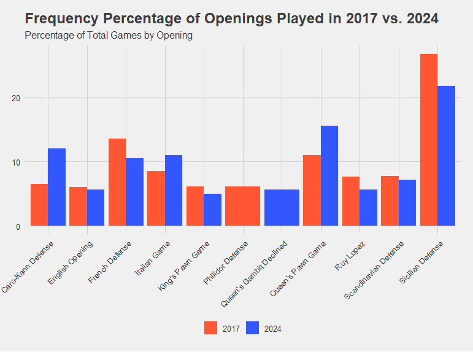

Apparently, “The Queen’s Gambit” made it to the top ten in 2024: the initial hypothesis seems reinforced. However, correlation does not imply causation.

Let us explore further and check how popular the opening ‘The Queen’s Gambit’ is among those who have just started playing. The hypothesis is that here the presence of such an opening should be higher in this range, as this is probably where most of the players who started playing chess after seeing the series are to be found.

```r
data_2024 <- data_2024 %>%
  mutate(Rating_Difference = abs(WhiteElo - BlackElo)) %>%
  mutate(average_elo = (WhiteElo + BlackElo) /2) %>%
  filter(Rating_Difference <= 400)

data_2024 <- data_2024 %>%
  mutate(are_beginners = cut(average_elo,
                             breaks = c(-Inf, 500, Inf),
                             labels = c("Yes", "No")))

# Modify the data to show beginners
opening_frequency_2024_rating_range <- data_2024 %>%
  group_by(simplified_opening, are_beginners) %>%
  summarize(count = n(), .groups = 'drop') %>%
  mutate(total_count = sum(count),
         percentage = (count / total_count) * 100) %>%
  slice_max(order_by = count, n = 10)

# Create a color column based on specific openings
opening_frequency_2024_rating_range <- opening_frequency_2024_rating_range %>%
  mutate(color = ifelse(simplified_opening %in% c("Queen's Gambit Declined", "Queen's Pawn Game"), "Possible 'The Queen's Gambit' Influence", "Completely Different Openings"))
```

Now, let’s check the results.

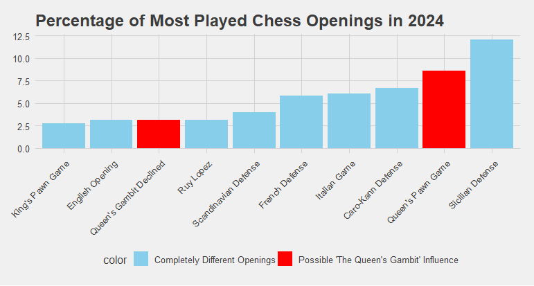

Apparently, there is no significant difference between the two graphs; thus, we must be cautious in concluding that the presence of ‘The Queen’s Gambit’ opening in 2024 is a direct result of the Netflix series.

It would be interesting to see how this analysis would look with a dataset from 2020, the year the series was released.